# 5 分析

## 5.1 指標によるジャンル評価の変化

| ジャンル | 作品数 | 興収中央値（百万ドル） | 倍率中央値 | 興収順位 | 倍率順位 |
| --- | --- | --- | --- | --- | --- |
| Animation | 278 | 189.31 | 2.93 | 1 | 2 |
| Action | 1412 | 70.87 | 1.87 | 2 | 4 |
| Adventure | 325 | 43.23 | 1.90 | 3 | 3 |
| Biography | 312 | 31.64 | 1.48 | 4 | 7 |
| Horror | 254 | 29.95 | 3.05 | 5 | 1 |
| Comedy | 1496 | 27.39 | 1.79 | 6 | 5 |
| Drama | 868 | 21.92 | 1.52 | 7 | 6 |
| Crime | 400 | 18.71 | 1.31 | 8 | 8 |

出所：保存済みKaggleデータ、筆者集計。50作品以上の8ジャンル間の順位。順位は標本上の記述であり、有意差順位ではない。

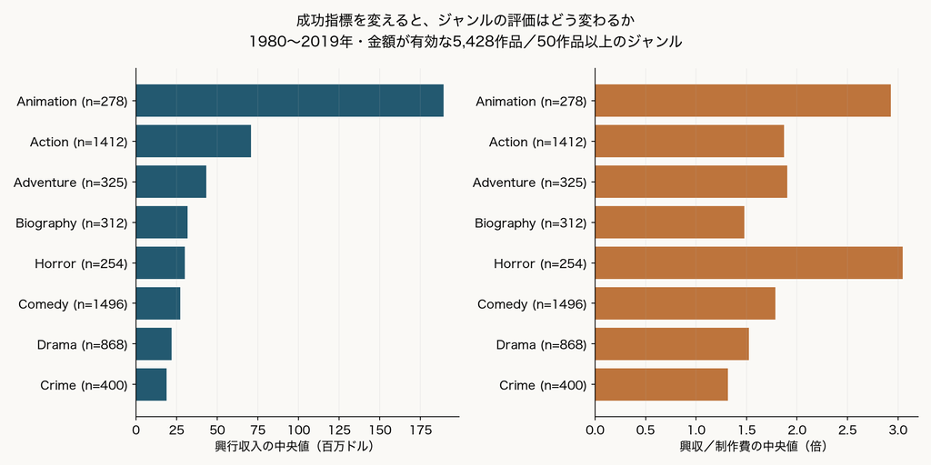

図 5.1: ジャンル別の興収中央値と制作費倍率中央値。出所：筆者集計。

アニメーションの興収中央値は約1億8,931万ドル、ホラーは約2,995万ドルである。一方、倍率中央値はアニメーション2.93倍、ホラー3.05倍である。ホラーは規模では5位、倍率では1位となる。アクションは規模2位から倍率4位、伝記は4位から7位へ変わる。指標によって各ジャンルの位置づけが異なる。ただしホラーとアニメーションの倍率中央値は近く、再抽出区間も重なるため、ホラーの優越性を確定する結果ではない。

## 5.2 平均と極端値

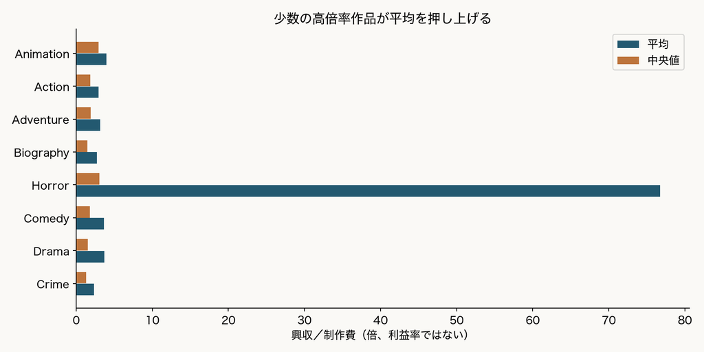

図 5.2: ジャンル別の倍率平均と中央値。出所：筆者集計。

ホラーの倍率平均は76.76倍だが、中央値は3.05倍である。全体の倍率上位1%（29.87倍超）を除くと、ホラーは254作品から236作品となり、平均5.04倍、中央値2.75倍になる。同じ処理後のアニメーションの中央値は2.92倍で、両者の順位は逆転する。これは極端な作品が誤りである証明ではなく、比較がそれらに依存する程度を示す。

全体では興収上位10%の543作品が興収合計の52.6%を占めた。倍率の極端値と、興収規模の集中は別の概念であるため、別々に示す。

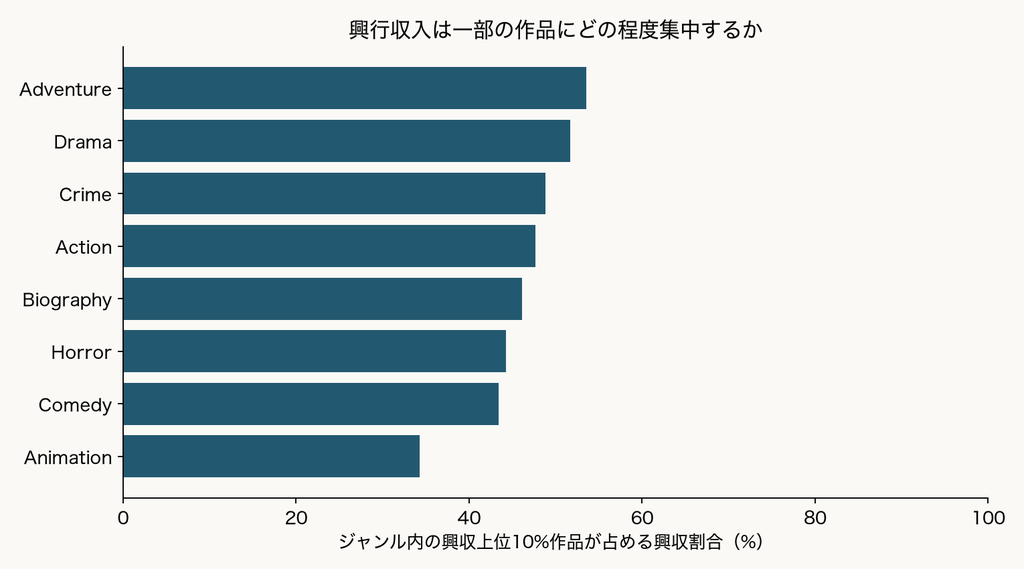

図 5.3: ジャンル内の興収上位10%作品への集中。出所：筆者集計。

## 5.3 予算帯の比較

| 制作費帯 | 作品数 | 興収中央値（百万ドル） | 倍率平均 | 倍率中央値 |
| --- | --- | --- | --- | --- |
| 1500万ドル未満 | 1904 | 10.40 | 14.29 | 1.80 |
| 1500万〜5000万ドル未満 | 2280 | 40.46 | 2.56 | 1.57 |
| 5000万ドル以上 | 1244 | 183.92 | 2.77 | 2.24 |

出所：筆者集計。名目ドルによる区分。低予算群の平均倍率14.29倍に対し、中央値は1.80倍である。高予算群の中央値は2.24倍であり、平均倍率から「低予算ほど典型的成果が高い」と結論づけることはできない。

予算の境界を1,000万・3,000万ドルへ変えると、倍率中央値は低予算2.02倍、中予算1.50倍、高予算2.06倍となる。各年の相対的な予算順位による3区分では2.01倍、1.61倍、1.96倍となる。低予算と高予算の優劣は区分方法でも変わるため、一律の序列は示さない。

## 5.4 公開年・ジャンルを考慮した補助分析

興収の対数を制作費の対数・ジャンル・公開年で説明したモデルでは、制作費の係数は0.910、95%信頼区間は0.863〜0.958であった。モデル上、他の投入条件を一定とすると、制作費が1%高い作品は興収が約0.91%高い関係にある。これは制作費を増やせばその通り興収が増えるという効果ではない。群別中央値の比較とは対象とする関係が異なり、順位の正しさを保証しない。

決定係数は0.473である。未知作品に対する予測精度としては解釈しない。

## 5.5 対象選択の影響

従来対象の倍率中央値は2.35倍、今回全体は1.83倍、追加作品のみは0.66倍である。前期の選定条件を満たす作品の方が、記述上、興行成果が高い。結合を外したことで成果の低い作品も加わり、見え方が変化した。ただし投票条件だけの因果効果とは言えず、タイトル照合、収録範囲、年代・ジャンル構成などの違いも含まれる。

2020年を追加した集計と年代・予算帯別集計は付属CSVに保存した。2020年は追加数が少なく、その年の映画市場を代表した比較とは扱わない。

## 5.6 別資料の金額による追加検証

収集後の出典照合で見つかった差を受け、Paranormal Activityの制作費だけを450,000ドルにしたシナリオを追加した。主結果は元CSVのまま保持する。

| 対象 | 元データの平均倍率 | 制作費1件を替えた平均倍率 | 中央値（両方共通） |
| --- | --- | --- | --- |
| 全体 | 6.72 | 4.43 | 1.83 |
| ホラー | 76.76 | 27.70 | 3.05 |
| 1,500万ドル未満 | 14.29 | 7.74 | 1.80 |